# Chadeau_Valerie_1_notebook_nettoyage donnees_analyse_062022

```python
from IPython.core.display import display, HTML
f = open("Chadeau_Valerie_4_sommaire_notebook1_062022.html", "r", encoding="utf-8")
display(HTML(f.read()))
```

TOP  
Partie 1 : Librairies et fonctions

- 1.1 - Importation les librairies

- 1.2 - Déclaration des fonctions

Partie 2 : Importer les fichiers et initialiser les Dataframe

- 2.1 - Importation et analyse du fichier billets.csv

- 2.2 - Traitement des valeurs manquantes

- a) Régression linéaire - Librairie Scikit-Learn

- b) Régression linéaire - Librairie Statsmodel

- c) Validation pré-requis régression linéaire

- d) Prédictions données manquantes

Partie 3 : La Mission

- 3.1 - Analyses univariées

- a) Distribution des variables

- b) Corrélation entre variables

- 3.2 - Analyses bivariées

- Analyse billets vrais et faux

- Distribution des variables en fonction des modalités "True" et "False" de la variable 'is_genuine'

- 3.3 - Les modélisations

- a) Apprentissage non supervisé : algorithme de clustering : KMEANS

- b) Apprentissage supervisé : REGRESSION LOGISTIQUE (librairie Scikit-Learn)

- c) Apprentissage supervisé : REGRESSION LOGISTIQUE (librairie StatsModels)

- d) Sauvegarde du modèle optimal

# Projet 10 - Détectez des faux billets avec R ou Python

[figure not shown]

Consultant Data Analyst dans une entreprise spécialisée dans la data, je dois réaliser une prestation en régie au sein de l’Organisation nationale de lutte contre le faux-monnayage (ONCFM) : mettre en place des méthodes d’identification des contrefaçons des billets en euros.

### Ce programme est organisé en plusieurs partie :

**Partie 1 :** Librairies et fonctions

**Partie 2 :** Importer les fichiers et initialiser les Dataframe

**Partie 3 :** La mission

**Conclusion**

## NOTEBOOK 1 - CHARGEMENT, NETTOYAGE DES DONNEES & ANALYSE

## Partie 1 - Librairies et fonctions

### 1.1 - Importation des librairies

```python
import pandas as pd
import numpy as np
import re
import matplotlib.pyplot as plt
import seaborn as sns
import datetime
import statsmodels.api as sm
import statsmodels.formula.api as smf
from sklearn.model_selection import train_test_split
from sklearn.linear_model import LinearRegression
from sklearn import datasets
from sklearn import svm
from sklearn import metrics
import scipy.stats as st
from scipy.stats import jarque_bera
import math
import statsmodels.api as sm
import scipy.stats as stats
from scipy.stats import anderson
from statsmodels.stats.diagnostic import het_white , normal_ad
from statsmodels.stats.api import  het_breuschpagan
from statsmodels.compat import lzip
from statsmodels.stats.outliers_influence import variance_inflation_factor
from sklearn import decomposition, preprocessing
from sklearn.cluster import KMeans
from scipy.stats import ks_2samp
from scipy.cluster.hierarchy import dendrogram, linkage, fcluster
from sklearn import decomposition, preprocessing
from sklearn import cluster, metrics
from sklearn import decomposition
from sklearn.cluster import AgglomerativeClustering
from sklearn.metrics import accuracy_score
from scipy.stats import shapiro
from sklearn.linear_model import LogisticRegression
from sklearn.metrics import confusion_matrix
from sklearn.model_selection import GridSearchCV,cross_val_score, StratifiedKFold, train_test_split
from sklearn.pipeline import Pipeline
from sklearn.preprocessing import StandardScaler
from sklearn import set_config
set_config(display='diagram')



#Permet d'afficher toutes les lignes d'une liste
pd.set_option("max_rows", None)

#Permet l'affichage de tous les résultats d'une cellule (pas seulement le dernier)
from IPython.core.interactiveshell import InteractiveShell
InteractiveShell.ast_node_interactivity = "all"

#Permet de définir des paramètres d'affichage pour l'ensemble des graphiques
from pylab import rcParams
```

### 1.2 - Déclaration des fonctions

```python
#Fonction affichage matrice de confusion
def matrice_confusion(conf):
    print('\033[1m','Matrice de confusion : ','\033[0m')
    print("-----------------------")

    class_names=[0,1] # name  of classes
    memo=fig, ax = plt.subplots()
    tick_marks = np.arange(len(class_names))
    memo=plt.xticks(tick_marks, class_names)
    memo=plt.yticks(tick_marks, class_names)

    # Création de la matrice de confusion sous forme de heatmap
    memo=sns.heatmap(pd.DataFrame(conf), annot=True, cmap="YlGnBu" ,fmt='g')
    memo=ax.xaxis.set_label_position("top")
    memo=plt.tight_layout()
    memo=plt.ylabel('Valeurs réelles')
    memo=plt.xlabel('Valeurs prédites')
    memo=plt.Text(0.5,257.44,'Predicted label')
    memo=plt.show()


#Fonction affichage ROC Curve
def roc(y_test,y_pred_proba):
    print('\033[1m','Courbe ROC : ','\033[0m')
    print("--------------")
    fpr, tpr, _ = metrics.roc_curve(y_test,  y_pred_proba)
    auc = metrics.roc_auc_score(y_test, y_pred_proba)
    memo=plt.plot(fpr,tpr,label="data 1, auc="+str(auc))
    memo=plt.xlabel('False Positive Rate')
    memo=plt.ylabel('True Positive Rate')
    memo=plt.legend(loc=4)
    memo=plt.show()
```

## Partie 2 - Importer les fichiers et initialiser les Dataframes

### 2.1 - Importation et analyse du fichier billets.csv

```python
#Importation dans un dataframe,vérification du bon chargement des données et de la cohérence du type des colonnes

billets=pd.read_csv('billets.csv',sep=";")
billets.head()
billets.shape
billets.dtypes
billets.isna().sum()
print("Lignes en double : ",billets.duplicated().sum())
billets.describe()
```

|  | is_genuine | diagonal | height_left | height_right | margin_low | margin_up | length |
| --- | --- | --- | --- | --- | --- | --- | --- |
| 0 | True | 171.81 | 104.86 | 104.95 | 4.52 | 2.89 | 112.83 |
| 1 | True | 171.46 | 103.36 | 103.66 | 3.77 | 2.99 | 113.09 |
| 2 | True | 172.69 | 104.48 | 103.50 | 4.40 | 2.94 | 113.16 |
| 3 | True | 171.36 | 103.91 | 103.94 | 3.62 | 3.01 | 113.51 |
| 4 | True | 171.73 | 104.28 | 103.46 | 4.04 | 3.48 | 112.54 |

```
(1500, 7)
```

```
is_genuine         bool
diagonal        float64
height_left     float64
height_right    float64
margin_low      float64
margin_up       float64
length          float64
dtype: object
```

```
is_genuine       0
diagonal         0
height_left      0
height_right     0
margin_low      37
margin_up        0
length           0
dtype: int64
```

```
Lignes en double :  0
```

|  | diagonal | height_left | height_right | margin_low | margin_up | length |
| --- | --- | --- | --- | --- | --- | --- |
| count | 1500.000000 | 1500.000000 | 1500.000000 | 1463.000000 | 1500.000000 | 1500.00000 |
| mean | 171.958440 | 104.029533 | 103.920307 | 4.485967 | 3.151473 | 112.67850 |
| std | 0.305195 | 0.299462 | 0.325627 | 0.663813 | 0.231813 | 0.87273 |
| min | 171.040000 | 103.140000 | 102.820000 | 2.980000 | 2.270000 | 109.49000 |
| 25% | 171.750000 | 103.820000 | 103.710000 | 4.015000 | 2.990000 | 112.03000 |
| 50% | 171.960000 | 104.040000 | 103.920000 | 4.310000 | 3.140000 | 112.96000 |
| 75% | 172.170000 | 104.230000 | 104.150000 | 4.870000 | 3.310000 | 113.34000 |
| max | 173.010000 | 104.880000 | 104.950000 | 6.900000 | 3.910000 | 114.44000 |

SYNTHESE :  
-----------------  
==> **Description des données**  
- **'is_genuine' :** indicateur billet vrai ou faux - **'length' :** longueur du billet - **'height_left' :** hauteur du billet sur le côté gauche - **'height_right' :** hauteur du billet sur le côté droit - **'margin_up':** marge supérieure du billet - **'margin_low' :** marge inférieure du billet - **'diagonal' :** diagonale du billet ==> **Unité de mesure :** millimètre  
==> le chargement des lignes semble cohérent (fonctions head et shape) : pas de problème de formatage incohérent de donnée  
==> le type de données est cohérent par rapport au nom des colonnes  
==> **1500** observations  
==> **7 variables** :  
- **1 variable qualitative** de type booléen ('is_genuine') - **6 variables quantitatives** de type float ('length', 'height_left', 'height_right', 'margin_up', 'margin_low', 'diagonal')  
==> **37 valeurs manquantes pour la variable "margin_low"** soit environ 2,4% des données

### 2.2 - Traitement des valeurs manquantes

**Méthode imputation données manquantes : régression linéaire multiple**  
Remplacement des valeurs manquantes par des valeurs prédites grâce à une régression linéaire multiple avec :  
**variable réponse :**  
margin_low  
**variables explicatives :**  
X1=diagonal  
X2=height_left  
X3=height_right  
X4=margin_up  
X5=length  
Le dataframe initial sera divisé en 2:  
- un **dataframe sans valeur manquantes** (pour entrainer le modèle de régression liniéaire) - un **dataframe ne contenant que les lignes avec les valeurs manquantes** sur lequel sera appliqué le modèle Cette régression sera effectuée avec les 2 librairies : Scikit-Learn et StatsModels. Les tests seont réalisés à un niveau 𝛼=5 %

### **a) Régression linéaire - Librairie Scikit-Learn**

```python
#Régression linéaire multiple // Bibliothèque sklearn

billets_sansna=billets.dropna(inplace=False).copy()
billets_na=billets[billets.isna().any(axis=1)].copy()
features_cols=['diagonal','height_left','height_right','margin_up','length']
X_train_reg=billets_sansna[features_cols]
y_train_reg=billets_sansna['margin_low']
X_test_reg=billets_na[features_cols]
y_test_reg=billets_na['margin_low']


#Instanciation du modèle
linreg=LinearRegression()

#Entrainement sur jeu de test
linreg.fit(X_train_reg,y_train_reg)


#Précision du modèle
precision = linreg.score(X_train_reg,y_train_reg)
print("Score régression linéaire (R²): ",precision*100)


droit_x=linreg.coef_[0]
droit_y=linreg.intercept_

print(linreg.intercept_)
#print(linreg.coef_)
for x in zip(features_cols, linreg.coef_):
    print(x)

#Prédictions des valeurs
y_pred_train=linreg.predict(X_train_reg)
```

```
LinearRegression()
```

```
Score régression linéaire (R²):  47.73366973063956
22.994842714447856
('diagonal', -0.11105977752644251)
('height_left', 0.18412241799735088)
('height_right', 0.2571380497719558)
('margin_up', 0.2561879006258604)
('length', -0.4091029331994857)
```

### b) Régression linéaire - Librairie Statsmodel

```python
#Régression linéaire multiple // Bibliothèque statsmodels
model_reg = smf.ols("margin_low ~ diagonal + height_left + height_right + margin_up + length", data=billets).fit()
print(model_reg.summary())
```

```
                            OLS Regression Results
==============================================================================
Dep. Variable:             margin_low   R-squared:                       0.477
Model:                            OLS   Adj. R-squared:                  0.476
Method:                 Least Squares   F-statistic:                     266.1
Date:                Tue, 16 Aug 2022   Prob (F-statistic):          2.60e-202
Time:                        12:48:54   Log-Likelihood:                -1001.3
No. Observations:                1463   AIC:                             2015.
Df Residuals:                    1457   BIC:                             2046.
Df Model:                           5
Covariance Type:            nonrobust
================================================================================
                   coef    std err          t      P>|t|      [0.025      0.975]
--------------------------------------------------------------------------------
Intercept       22.9948      9.656      2.382      0.017       4.055      41.935
diagonal        -0.1111      0.041     -2.680      0.007      -0.192      -0.030
height_left      0.1841      0.045      4.113      0.000       0.096       0.272
height_right     0.2571      0.043      5.978      0.000       0.173       0.342
margin_up        0.2562      0.064      3.980      0.000       0.130       0.382
length          -0.4091      0.018    -22.627      0.000      -0.445      -0.374
==============================================================================
Omnibus:                       73.627   Durbin-Watson:                   1.893
Prob(Omnibus):                  0.000   Jarque-Bera (JB):               95.862
Skew:                           0.482   Prob(JB):                     1.53e-21
Kurtosis:                       3.801   Cond. No.                     1.94e+05
==============================================================================

Notes:
[1] Standard Errors assume that the covariance matrix of the errors is correctly specified.
[2] The condition number is large, 1.94e+05. This might indicate that there are
strong multicollinearity or other numerical problems.
```

```python
#Suppression variable non significative
model_regbis = smf.ols("margin_low ~ height_left + height_right + margin_up + length", data=billets).fit()
print(model_regbis.summary())
```

```
                            OLS Regression Results
==============================================================================
Dep. Variable:             margin_low   R-squared:                       0.475
Model:                            OLS   Adj. R-squared:                  0.473
Method:                 Least Squares   F-statistic:                     329.5
Date:                Tue, 16 Aug 2022   Prob (F-statistic):          4.80e-202
Time:                        12:48:54   Log-Likelihood:                -1004.9
No. Observations:                1463   AIC:                             2020.
Df Residuals:                    1458   BIC:                             2046.
Df Model:                           4
Covariance Type:            nonrobust
================================================================================
                   coef    std err          t      P>|t|      [0.025      0.975]
--------------------------------------------------------------------------------
Intercept        5.2656      7.048      0.747      0.455      -8.560      19.091
height_left      0.1779      0.045      3.971      0.000       0.090       0.266
height_right     0.2550      0.043      5.917      0.000       0.170       0.340
margin_up        0.2588      0.064      4.012      0.000       0.132       0.385
length          -0.4136      0.018    -22.930      0.000      -0.449      -0.378
==============================================================================
Omnibus:                       75.632   Durbin-Watson:                   1.885
Prob(Omnibus):                  0.000   Jarque-Bera (JB):               99.244
Skew:                           0.489   Prob(JB):                     2.81e-22
Kurtosis:                       3.820   Cond. No.                     1.04e+05
==============================================================================

Notes:
[1] Standard Errors assume that the covariance matrix of the errors is correctly specified.
[2] The condition number is large, 1.04e+05. This might indicate that there are
strong multicollinearity or other numerical problems.
```

==> **R2 ajusté (présence de plusieurs variables) : 0,473** qui n'est pas très élevé là aussi (seul 47% des points peuvent être expliqués par le modèle) ==> Toutes les variables du modèles sont significatives (leur p-value <5%). Nous pouvons donc utiliser ce modèle.

### c) Validation pré-requis régression linéaire

**Réalisation des tests avec un niveau de risque $\alpha=5$%.**  
**1. Normalité des résidus**  
L’objectif est de s’assurer que les résidus suivent une loi normale  
L'échantillon étant < 5000 observations, on peut utiliser **le test de Shapiro-Wilk** pour démontrer la normalité de la distribution. On pose :  
H0 : Les résidus suivent une loi normale si p-value > 5%  
H1 : Les résidus ne suivent pas une loi normale si p-value < 5%  
Utilisation d'autres tests **(QQPlot, Test Jarque-Berra)** afin de valider si les résidus sont distribués normalement.

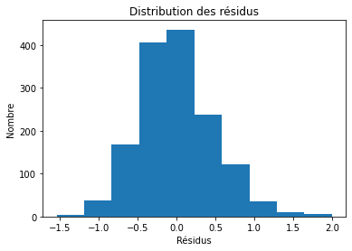

```
 Test de Shapiro-Wilk
 p-value =  5.929039204044528e-11
```

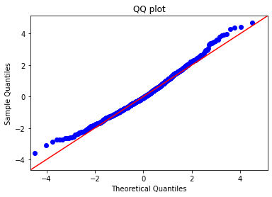

```
 Test de Jarque-Berra:  0.0
```

```python
#Test de Shapiro- Wilk
residues=model_regbis.resid
memo=plt.hist(residues)
memo=plt.ylabel('Nombre')
memo=plt.xlabel('Résidus')
memo=plt.title('Distribution des résidus')
memo=plt.show()
print('\033[1m','Test de Shapiro-Wilk','\033[0m')
print(" p-value = ",shapiro(residues)[1])

#Diagramme Quantile-Quantile (QQPlot qui permet d'évaluer la pertinence de l'ajustement d'une distribution donnée
#à un modèle théorique (ici une droite).
fig = sm.qqplot(residues, stats.t, fit=True,line='45')
memo=plt.title("QQ plot")
memo=plt.show()

#Test de Jarque-Berra (teste si kurtosis et coefficient d'asymétrie sont les mêmes que ceux d'une loi normale
#de même espérance et variance.
x, pval = jarque_bera(residues)
print('\033[1m',"Test de Jarque-Berra:",'\033[0m',pval)
```

**Quel que soit le test, p_value < 5% ==> on rejette H0 : la distribution des résidus ne suit pas une loi normale**

**2. L’égalité des variances (homoscédasticité)**  
La variance des résidus doit être constante : on vérifie cette condition via le test statistique **Breusch-Pagan.**  
On pose :  
H0 : Les résidus présentent une égalité de variance (il y a homoscédasticité) si p-value > 5%  
H1 : Les résidus ne présentent pas une égalité de variance si p-value < 5%

```python
names = ['Lagrange multiplier statistic', 'p-value',
         'f-value', 'f p-value']
test_result = het_breuschpagan(model_regbis.resid,model_regbis.model.exog)
lzip(names, test_result)
```

```
[('Lagrange multiplier statistic', 80.45052267061047),
 ('p-value', 1.3981519938685083e-16),
 ('f-value', 21.210246717594387),
 ('f p-value', 5.0911563785029245e-17)]
```

**3. Vérification colinéarité des variables**  
La variance des résidus doit être constante : on la réalise en étudiant **le facteur d’inflation de variance(VIF) qui va permettre d'évaluer si les facteurs sont corrélés les uns aux autres.**

```python
variables = model_regbis.model.exog
[variance_inflation_factor(variables, i) for i in np.arange(1,variables.shape[1])]
```

```
[1.1352454885217662,
 1.2296897649621907,
 1.4040824245306425,
 1.5630988358433224]
```

Ici, tous les coefficients sont inférieurs à 10, **il n'y a donc pas de problème de colinéarité.**

CONCLUSION  
La normalité des résidus et l'égalite des variances ne sont pas vérifiés dans notre échantillon.  
Néanmoins, l'observation des résidus, le fait qu'ils ne soient pas très différents d'une distribution symétrique, et le fait que l'échantillon soit de taille suffisante (supérieure à 30) permettent de dire que les résultats obtenus par le modèle linéaire gaussien ne sont pas absurdes, même si le résidu n'est pas considéré comme étant gaussien.  
Nous pouvons donc utiliser le modèle de régression linéaire afin de déterminer les valeurs manquantes de notre jeu de données.

### **d) Prédictions données manquantes**

```python
#Prédictions des valeurs avec régression linéaire et constitution du dataframe final

billets_na['margin_low_pred_reg']=model_regbis.predict(X_test_reg)
billets.loc[billets['margin_low'].isna(),'margin_low'] =billets_na['margin_low_pred_reg']
billets.isna().sum()
```

```
is_genuine      0
diagonal        0
height_left     0
height_right    0
margin_low      0
margin_up       0
length          0
dtype: int64
```

==> Plus de données manquantes dans le fichier initial.  
==> Visualisation par graphique nuage de points des données (variable 'margin_low' vs les autres variables) créées avec la régression linéaire afin de vérifier que les données ne sont pas aberrantes

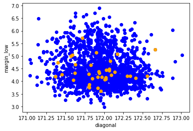

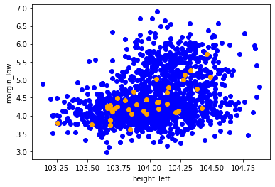

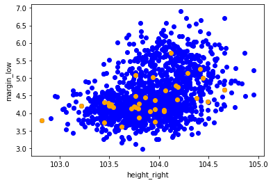

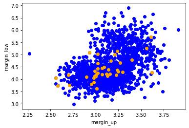

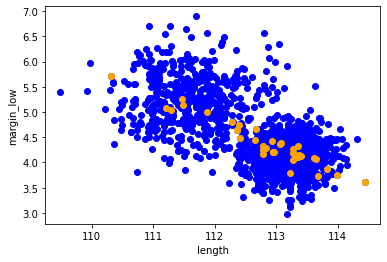

```python
for col in ['diagonal','height_left','height_right','margin_up','length']:
    memo=plt.scatter(billets[col],billets['margin_low'],c="blue")
    memo=plt.scatter(billets_na[col],billets_na['margin_low_pred_reg'],c="orange")
    memo=plt.xlabel(col)
    memo=plt.ylabel('margin_low')
    memo=plt.show()
```

## Partie 3 - La mission

### 3.1 Analyses univariées

### a) Distribution des variables

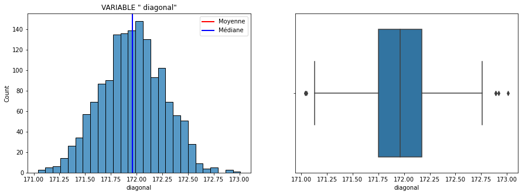

```
 Moyenne :  171.96
 Médiane :  171.96
 Kurtosis :  -0.13
 Écart-type :  -0.13
 Test de Shapiro-Wilk / p-value :   0.32
 avec H0 : La variable suit une loi normale si p-value > 5%
 ==> La variable ' diagonal 'suit une loi normale
```

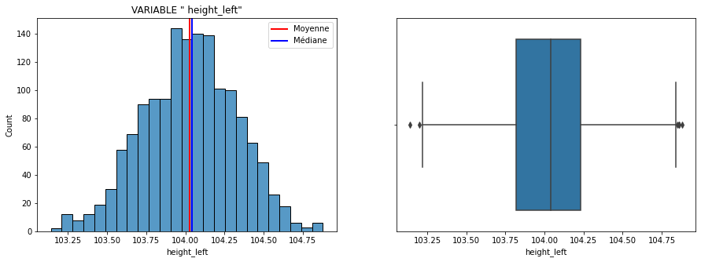

```
 Moyenne :  104.03
 Médiane :  104.04
 Kurtosis :  -0.2
 Écart-type :  -0.2
 Test de Shapiro-Wilk / p-value :   0.05
 avec H0 : La variable suit une loi normale si p-value > 5%
 ==> La variable ' height_left 'suit une loi normale
```

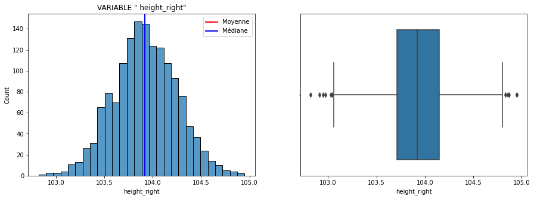

```
 Moyenne :  103.92
 Médiane :  103.92
 Kurtosis :  -0.03
 Écart-type :  -0.03
 Test de Shapiro-Wilk / p-value :   0.98
 avec H0 : La variable suit une loi normale si p-value > 5%
 ==> La variable ' height_right 'suit une loi normale
```

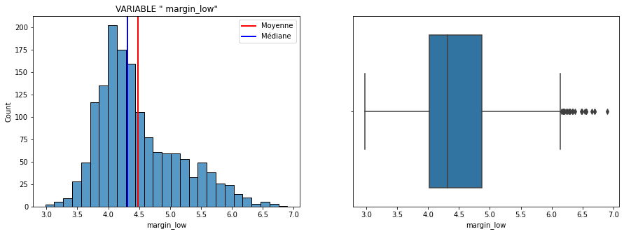

```
 Moyenne :  4.48
 Médiane :  4.31
 Kurtosis :  0.25
 Écart-type :  0.25
 Test de Shapiro-Wilk / p-value :   0.0
 avec H0 : La variable suit une loi normale si p-value > 5%
 ==> La variable  margin_low  ne suit pas une loi normale
```

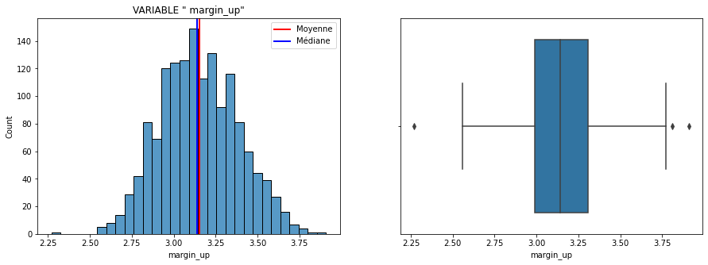

```
 Moyenne :  3.15
 Médiane :  3.14
 Kurtosis :  -0.25
 Écart-type :  -0.25
 Test de Shapiro-Wilk / p-value :   0.0
 avec H0 : La variable suit une loi normale si p-value > 5%
 ==> La variable  margin_up  ne suit pas une loi normale
```

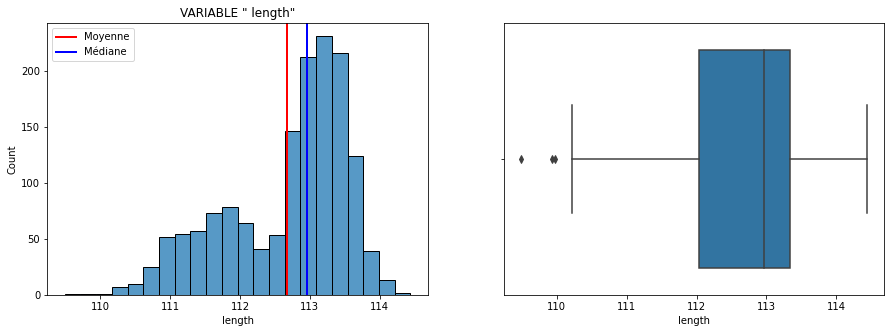

```
 Moyenne :  112.68
 Médiane :  112.96
 Kurtosis :  -0.28
 Écart-type :  -0.28
 Test de Shapiro-Wilk / p-value :   0.0
 avec H0 : La variable suit une loi normale si p-value > 5%
 ==> La variable  length  ne suit pas une loi normale
```

```python
for col in billets.select_dtypes('float'):
    memo=plt.figure(figsize=(15,5))
    memo=plt.subplot(121)
    memo=sns.histplot(data = billets, x=col)
    #memo=sns.distplot(billets[col])
    memo=plt.axvline(billets[col].mean(), color='r', linewidth=2,label='Moyenne')
    memo=plt.axvline(billets[col].median(), color='b', linewidth=2,label='Médiane')
    memo=plt.legend()
    memo=plt.title('VARIABLE " '+ col + '"')
    memo=plt.subplot(122)
    memo=sns.boxplot(x=billets[col])
    memo=plt.show(block=False)
    print ('\033[1m',"Moyenne :",'\033[0m', round(billets[col].mean(), 2))
    print ('\033[1m',"Médiane :",'\033[0m', round(billets[col].median(), 2))
    print ('\033[1m',"Kurtosis :",'\033[0m', round(billets[col].kurtosis(), 2))
    print ('\033[1m',"Écart-type :",'\033[0m', round(billets[col].kurtosis(), 2))
    shap=shapiro(billets[col])[1]
    print('\033[1m',"Test de Shapiro-Wilk / p-value : ",'\033[1m',round(shap,2))
    print(" avec H0 : La variable suit une loi normale si p-value > 5%")
    if (shap > 0.05):
        print(" ==> La variable '",col,"'suit une loi normale")
    else:
        print(" ==> La variable ",col," ne suit pas une loi normale")
    memo=plt.show()
```

### b) Corrélation entre variables

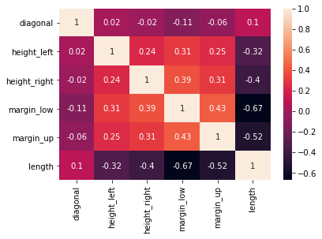

```python
memo=sns.heatmap(billets.loc[:, billets.columns != 'is_genuine'].corr().round(2),annot=True)
memo=plt.show()
```

==> Corrélation négative significative entre marges (haute ou basse) et longueur  
margin_low / length : -0.67  
margin_up / length : -0.52

### 3.2 Analyses bivariées

### **==> Analyse billets vrais et faux**

Comment sont répartis ces types de billets dans notre échantillon et quelle est la répartition des autres variables en fonction de ces 2 modalités.

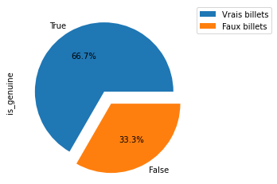

```python
#La répartition des types de billets dans l'échantillon
exploda = [0, 0.2]
labels=['Vrais billets', 'Faux billets']
memo=billets['is_genuine'].value_counts().plot.pie(labels=[True,False],autopct='%1.1f%%',explode=exploda)
memo=plt.legend(labels,bbox_to_anchor=(1.01, 1.01))
```

==> billets faux : 1/3 des cas du fichier  
==> billets vrais : 2/3 des cas du fichier

```python
#Analyse billets vrais
billets_vrais=billets.loc[billets['is_genuine']==True]
billets_vrais.shape
billets_vrais.isna().sum()
billets_vrais.describe()


#Analyse billets faux
billets_faux=billets.loc[billets['is_genuine']==False]
billets_faux.shape
billets_faux.isna().sum()
billets_faux.describe()
```

```
(1000, 7)
```

```
is_genuine      0
diagonal        0
height_left     0
height_right    0
margin_low      0
margin_up       0
length          0
dtype: int64
```

|  | diagonal | height_left | height_right | margin_low | margin_up | length |
| --- | --- | --- | --- | --- | --- | --- |
| count | 1000.000000 | 1000.000000 | 1000.00000 | 1000.000000 | 1000.00000 | 1000.000000 |
| mean | 171.987080 | 103.949130 | 103.80865 | 4.118075 | 3.05213 | 113.202430 |
| std | 0.300441 | 0.300231 | 0.29157 | 0.317547 | 0.18634 | 0.359552 |
| min | 171.040000 | 103.140000 | 102.82000 | 2.980000 | 2.27000 | 111.760000 |
| 25% | 171.790000 | 103.740000 | 103.61000 | 3.910000 | 2.93000 | 112.950000 |
| 50% | 171.990000 | 103.950000 | 103.81000 | 4.120000 | 3.05000 | 113.205000 |
| 75% | 172.200000 | 104.140000 | 104.00000 | 4.340000 | 3.18000 | 113.460000 |
| max | 172.920000 | 104.860000 | 104.95000 | 5.040000 | 3.74000 | 114.440000 |

```
(500, 7)
```

```
is_genuine      0
diagonal        0
height_left     0
height_right    0
margin_low      0
margin_up       0
length          0
dtype: int64
```

|  | diagonal | height_left | height_right | margin_low | margin_up | length |
| --- | --- | --- | --- | --- | --- | --- |
| count | 500.000000 | 500.000000 | 500.000000 | 500.000000 | 500.000000 | 500.000000 |
| mean | 171.901160 | 104.190340 | 104.143620 | 5.214001 | 3.350160 | 111.630640 |
| std | 0.306861 | 0.223758 | 0.270878 | 0.550450 | 0.180498 | 0.615543 |
| min | 171.040000 | 103.510000 | 103.430000 | 3.820000 | 2.920000 | 109.490000 |
| 25% | 171.690000 | 104.040000 | 103.950000 | 4.840000 | 3.220000 | 111.200000 |
| 50% | 171.910000 | 104.180000 | 104.160000 | 5.180000 | 3.350000 | 111.630000 |
| 75% | 172.092500 | 104.332500 | 104.320000 | 5.590000 | 3.472500 | 112.030000 |
| max | 173.010000 | 104.880000 | 104.950000 | 6.900000 | 3.910000 | 113.850000 |

Pour les 2 types de billets : des valeurs extrêmes mais pas aberrantes.  
**Portait type "billet vrai" :**  
**--------------------------------**  
diagonal = 171.98  
height_left = 103.94  
height_right = 103.80  
margin_low = 4.11  
margin_up = 3.05  
length = 113.20  
**Portait type "billet faux" :**  
**--------------------------------**  
diagonal = 171.90  
height_left = 104.19  
height_right = 104.14  
margin_low = 5.21  
margin_up = 3.35  
length = 111.63  
Un faux billet est un billet plus court et plus haut qu'un billet vrai.

### **==> Distribution des variables en fonction des modalités "True" et "False" de la variable 'is_genuine'**

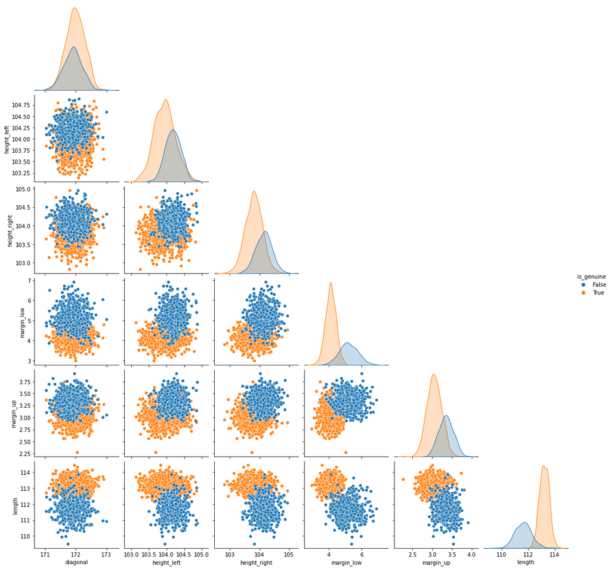

```python
#Distribution via des pairplots
memo=sns.pairplot(billets, hue='is_genuine', corner=True)
```

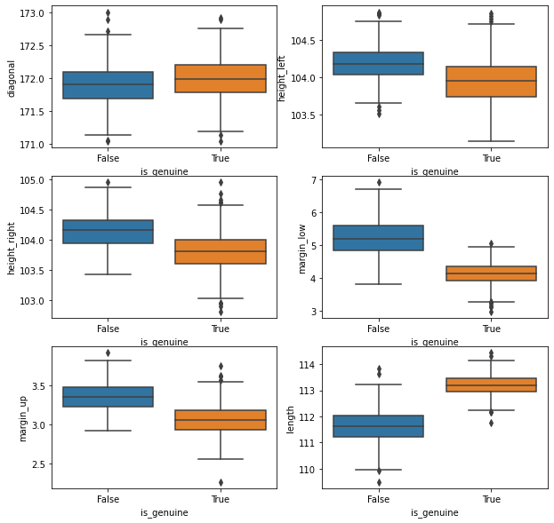

```python
#Distribution via des boxplots
memo=plt.figure(figsize=(10, 10))
memo=plt.subplot(321)
memo=sns.boxplot(x="is_genuine", y="diagonal", data=billets)
memo=plt.subplot(322)
memo=sns.boxplot(x="is_genuine", y="height_left", data=billets)
memo=plt.subplot(323)
memo=sns.boxplot(x="is_genuine", y="height_right", data=billets)
memo=plt.subplot(324)
memo=sns.boxplot(x="is_genuine", y="margin_low", data=billets)
memo=plt.subplot(325)
memo=sns.boxplot(x="is_genuine", y="margin_up", data=billets)
memo=plt.subplot(326)
memo=sns.boxplot(x="is_genuine", y="length", data=billets)
memo=plt.show()
```

Les dimensions les plus significatives qui permettent de distinguer les vrais des faux billets sont les variables "length" et "margin_low" lorsqu'on observe les ditributions via des pairplot.  
En revanche la distribution des données via des boxplots montrent des différences significatives entre les différentes variables suivant le type de billet à l'exception de la variable 'diagonal'.

### 3.3 Les modélisations

### **a) Apprentissage non supervisé : algorithme de clustering : KMEANS**

A l'issu de ce clustering, les centroïdes trouvés seront utilisés afin de réaliser la prédiction.  
Cet algorithme sera réalisé pour plusieurs tailles de clusters (maximum choisi =10).  
Son objectif est de trouver des groupes en faisant en sorte de minimiser l'inertie intraclasse. Après avoir déterminé aléatoire un centroïde pour chaque cluster, on associe à chaque point du nuage le cluster du centroïde dont il est le plus proche. A la fin du traitement on calcule le centre de gravité du nuage, on déplace le centroïde sur ce point et on associe à nouveau pour chaque point du nauge le cluster du centroïde le plus proche. Ce traitement est réalisé jusqu'à ce que les centroïdes conservent la même position d'une itération sur l'autre.  
2 calculs vont nous permettre de valider le nombre de clusters à choisir : le calcul du **coefficient de silhouette** et celui du **coefficient d'inertie.**

### * Calcul métrique silhouette

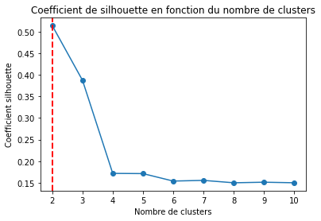

```python
#Calcul  de la métrique "silhouette" :
#
#le coefficient de silhouette est une mesure de qualité d'une partition d'un ensemble de données en clustering.
#C'est une mesure de la similitude d'un objet avec son propre cluster (distance moyenne avec les points du même groupe
#que lui :cohésion)par rapport à d'autres clusters (distance moyenne avec les points des autres groupes voisins : séparation).
#Si cette différence est négative, le point est en moyenne plus proche du groupe voisin que du sien : il est donc mal classé.
#A l'inverse, si cette différence est positive, le point est en moyenne plus proche de son groupe que du groupe voisin : il est
#donc bien classé.

# Centrage et Réduction des données afin que les données elles aient le même poids (utilisation de la méthode Standardscaler)
#X = billets.values
features_cols=['diagonal','height_left','height_right','margin_up','margin_low','length']
X = billets[features_cols].values
X_cr = preprocessing.StandardScaler().fit_transform(X)


#Liste de stockage des coefficients
silhouettes = []

#Boucle itérative de 2 à 10 clusters
for k in range(2, 11):
    #Création et ajustement d'un modèle pour chaque k
    #cls = cluster.KMeans(n_clusters=k)
    cls = cluster.KMeans(n_clusters=k,max_iter=50, random_state=2000)
    #memo=cls.fit(X_cr)
    memo=cls.fit(X)

    #Stockage des coefficients associés
    #silh = metrics.silhouette_score(X_cr, cls.labels_)
    silh = metrics.silhouette_score(X, cls.labels_)
    silhouettes.append(silh)

#Visualisation des valeurs de coefficient de silhouette pour chaque nombre de cluster
memo=plt.plot(range(2, 11), silhouettes, marker='o')
memo=plt.title('Coefficient de silhouette en fonction du nombre de clusters')
memo=plt.xlabel('Nombre de clusters')
memo=plt.ylabel('Coefficient silhouette')
memo=plt.axvline(x = 2.0, color ="red", linestyle ="--", linewidth=2)
memo=plt.show()

#silhouettes
```

**==> Méthode sihouette : Nombre de clusters = 2**

### * Eboulis des valeurs propres

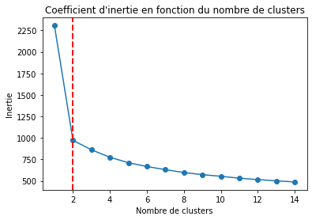

```python
#Calcul des coefficients d'inertie et utilisation méthode du coude (éboulis des valeurs propres)

inertia=[] #Liste coût du modèle
K_range=range(1,15)
for k in K_range:
    #model=KMeans(n_clusters=k,max_iter=50, random_state=2000).fit(X_cr) #On entraine le modèle
    model=KMeans(n_clusters=k,max_iter=50, random_state=2000).fit(X) #On entraine le modèle
    inertia.append(model.inertia_) #Cacul du coût du modèle + mémorisation dans liste
memo=plt.plot(K_range,inertia,marker='o')
memo=plt.xlabel('Nombre de clusters')
memo=plt.ylabel('Inertie')
memo=plt.title("Coefficient d'inertie en fonction du nombre de clusters")
memo=plt.axvline(x = 2.0, color ="red", linestyle ="--", linewidth=2)
#print(inertia)
```

==> Méthode du coude : à partir de 2 la courbe diminue moins rapidement.  
Le résultat est identique à celui de la méthode silhouette. On peut donc utiliser un **nombre de cluster=2** pour KMeans.

```python
#Clustering K-Means en 2 clusters

Cluster2 = cluster.KMeans(n_clusters=2,max_iter=50, random_state=2000)
#Cluster2.fit(X_cr)
Cluster2.fit(X)

np.unique(Cluster2.labels_,return_counts=True)

df_kmeans2=billets.copy()
df_kmeans2['Cluster']=Cluster2.labels_

centroides=Cluster2.cluster_centers_
```

```
KMeans(max_iter=50, n_clusters=2, random_state=2000)
```

```
(array([0, 1]), array([1016,  484], dtype=int64))
```

```
Vrais billets (= cluster 0) :
```

```
997
```

```
Faux billets (= cluster 1) :
```

```
481
```

```
Précision : 0.985


Matrice de confusion :
---------------------------
Cluster       0    1
is_genuine
False        19  481
True        997    3

 Matrice de confusion :
-----------------------
```

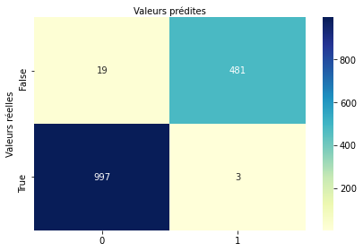

```python
print("Vrais billets (= cluster 0) :")
df_kmeans2.loc[(df_kmeans2['is_genuine']==True) & (df_kmeans2['Cluster']==0)].count()['Cluster']
print("Faux billets (= cluster 1) :")
df_kmeans2.loc[(df_kmeans2['is_genuine']==False) & (df_kmeans2['Cluster']==1)].count()['Cluster']

df_test_kmeans=df_kmeans2.copy()

print("Précision :",round(1-accuracy_score(df_test_kmeans['is_genuine'], df_test_kmeans['Cluster']),3))
print("\n\nMatrice de confusion :")
print("---------------------------")
print(pd.crosstab(df_test_kmeans['is_genuine'], df_test_kmeans['Cluster']),'\n')
#Affichage matrice de confusion
matrice_confusion(pd.crosstab(df_test_kmeans['is_genuine'], df_test_kmeans['Cluster']))
```

En comparant le cluster généré par kmeans et les labels initialement fournis, on obtient une précision de **98,5%** ce qui démontre une bonne efficacité du modèle obtenu.

### * Projection sur le 1er plan factoriel

```
PCA(n_components=6)
```

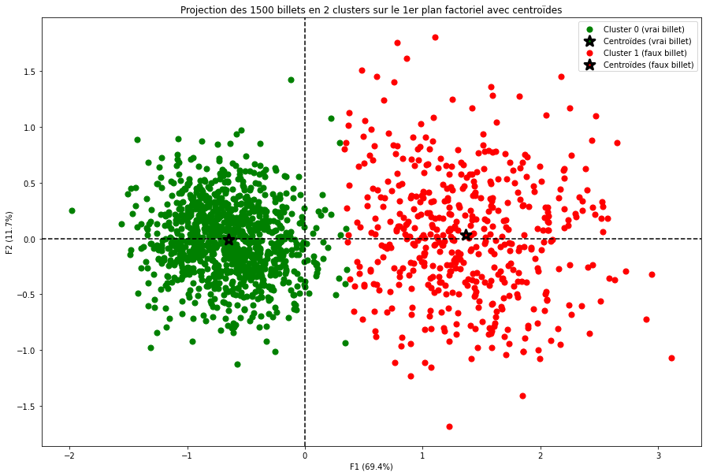

```python
#Calcul des composantes principales
model_pca = decomposition.PCA(n_components=6)
#model_pca.fit(X_cr)
model_pca.fit(X)

#Coordonnées factorielles
#X_projected = model_pca.transform(X_cr)
X_projected = model_pca.transform(X)
centroides_projected = model_pca.transform(centroides)

colors = np.array(["green", "red"])
memo=plt.figure(figsize=(15, 10))
for value in np.unique(Cluster2.labels_):
     selected = np.where(Cluster2.labels_ == value)
     if value==0:
        type_bil=' (vrai billet)'
     else:
        type_bil=' (faux billet)'
     memo=plt.scatter(X_projected[selected, 0], X_projected[selected,1],c=colors[value],label='Cluster ' + str(value) + type_bil,s=50)
     memo=plt.scatter(centroides_projected[value,0],centroides_projected[value,1],c=colors[value],marker = '*',
                         edgecolors = 'black',s=180,linewidth = 3,label='Centroïdes' + type_bil)
memo=plt.legend()
memo=plt.xlabel('F{} ({}%)'.format(1, round(100*model_pca.explained_variance_ratio_[0],1)))
memo=plt.ylabel('F{} ({}%)'.format(2, round(100*model_pca.explained_variance_ratio_[1],1)))
memo=plt.title("Projection des {} billets en 2 clusters sur le 1er plan factoriel avec centroïdes".format(X_projected.shape[0]))
memo=plt.axvline(x = 0, color ="black", linestyle ="--", linewidth=1.5)
memo=plt.axhline(y = 0, color ="black", linestyle ="--", linewidth=1.5)
memo=plt.show()
```

### * Prédiction sur les centroïdes

```python
#Test sur les centroides
#Constitution dataframe avec centroides
centroides_df=pd.DataFrame(centroides)
centroides_df.columns=features_cols
#Prédiction sur les centroides
centroides_df["cluster_pred"] = Cluster2.predict(centroides_df)
centroides_df
```

|  | diagonal | height_left | height_right | margin_up | margin_low | length | cluster_pred |
| --- | --- | --- | --- | --- | --- | --- | --- |
| 0 | 171.986998 | 103.951654 | 103.813337 | 3.058219 | 4.124064 | 113.196152 | 0 |
| 1 | 171.898492 | 104.193017 | 104.144855 | 3.347231 | 5.237659 | 111.591860 | 1 |

Les clusters prédits pour les centroides correspondent bien à leur cluster de rattachement.

### **b) Apprentissage supervisé : REGRESSION LOGISTIQUE (librairie Scikit-Learn)**

Il s'agit de réaliser une classification avec la variable catégorielle 'is_genuine' (variable expliquée) à partir des variables explicatives. Utilisation de la validation croisée stratifiée afin d'obtenir une évaluation plus robuste du modèle. Elle sépare la dataset d'origine en plusieurs blocs tout en préservant les proportions des classes dans chacun des blocs. Ici on prend n_splits = 5 (à chaque itération on utilisera 4 blocs pour entrainer le modèle et 1 bloc pour le tester) et l'option shuffle (les échantillons seront mélangés de façon aléatoire avant d'être répartis en blocs).

### * Initialisation des variables

```python
#Initialisation des variables pour la validation croisée
# y (variable expliquée):
y = billets['is_genuine']
y.replace([False,True], [0,1], inplace=True)

# X (variables explicatives):
X = billets.drop('is_genuine', axis=1)

# Initialisation de la validation croisée avec les caractéristiques souhaitées
cross_validation= StratifiedKFold(n_splits=5,random_state=42,shuffle=True)

clr = LogisticRegression()
#variable qui permettra de sauvegarder les accuracy pour chaque itération afin de pouvoir calculer la moyenne
accuracy=pd.Series(dtype=float)
```

### * Comparaison validation croisée modèle régression logistique avec et sans standardisation des données

```python
#Validation croisée pour modèle régression logistique avec standardisation des données
scaler=StandardScaler()
#Instanciation de l'objet pipeline
pipeline=Pipeline([('scaler',scaler),('classifier',clr)])
accuracy=cross_val_score(pipeline, X,y,cv=cross_validation)
print("Validation croisée régression logistique avec standardisation des données : ")
print("-----------------------------------------------------------------------------")
print(accuracy)
print('Mean accuracy =','{:.8f}'.format(accuracy.mean()))

#Validation croisée pour modèle régression logistique sans standardisation des données
#Instanciation de l'objet pipeline
pipelinebis=Pipeline([('classifier',clr)])
accuracy=cross_val_score(pipelinebis, X,y,cv=cross_validation)
print("\n\nValidation croisée régression logistique sans standardisation des données : ")
print("-----------------------------------------------------------------------------")
print(accuracy)
print('Mean accuracy =','{:.8f}'.format(accuracy.mean()))
```

```
Validation croisée régression logistique avec standardisation des données :
-----------------------------------------------------------------------------
[0.99666667 0.99       0.99       0.99666667 0.99      ]
Mean accuracy = 0.99266667


Validation croisée régression logistique sans standardisation des données :
-----------------------------------------------------------------------------
[0.99333333 0.98666667 0.98       0.99666667 0.99      ]
Mean accuracy = 0.98933333
```

Le modèle de régression logistique le plus performant est celui avec **la standardisation des données.**

### * Matrice de confusion (= tableau de contingence)

Elle permet d'évaluer les performances d'un modèle de classification. Elle compare les données réelles pour une variable cible à celles prédites par un modèle.

```
LogisticRegression()
```

```
 Matrice de confusion :
-----------------------
```

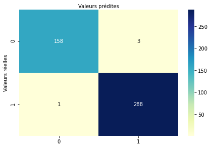

```
Accuracy: 99.11 %
Precision: 98.97 %
Recall (sensibilité): 99.65 %
```

```python
#Séparation jeu d'entrainement et jeu de test
X_train, X_test, y_train, y_test = train_test_split(X, y, test_size=0.3,random_state=42)

#Données standardisées
std_scale = preprocessing.StandardScaler().fit(X_train)
X_train_std = std_scale.transform(X_train)
X_test_std = std_scale.transform(X_test)

# on ajuste le modèle
clr = LogisticRegression()
clr.fit(X_train_std, y_train)

#on applique le modèle au jeu de test
y_pred=clr.predict(X_test_std)

#Affichage matrice de confusion
matrice_confusion(confusion_matrix(y_test, y_pred))

#Affichage métriques diverses
#print('\033[1m','Précision :',round(clr.score(X_train_std, y_train)*100,2),'%','\033[0m')
print('\033[1m',"\n\nAccuracy:",round(metrics.accuracy_score(y_test, y_pred)*100,2),'%')
print("Precision:",round(metrics.precision_score(y_test, y_pred)*100,2),'%')
print("Recall (sensibilité):",round(metrics.recall_score(y_test, y_pred)*100,2),'%''\033[0m')
```

**Précision = Nbre prédictions positives correctes/ Nbre prédictions positives correctes + Nbre prédictions positives incorrectes**  
= 288 /(288+3)  
**Accuracy = Nombre prédictions correctes/Nbre total prédictions**  
= (288+158) / (288+158+3+1)  
Recall = Nbre prédictions positives correctes/ Nbre prédictions positives correctes + Nbre prédictions négatives incorrectes  
(=pertinence de la sélection des cas positifs corrects)  
= 288 / (288 + 1)

### * ROC Curve (Receiver Operating Characteristic)

Cette courbe est une mesure de performance : elle donne le taux de vrais positifs en fonction du taux de faux positifs.Elle représente la sensibilité en fonction de la spécificité pour différents seuils de décision s et permet de nous indiquer si le classificateur est idéal en fonction de l'aire sous la courbe (=AUC (Area Under Roc)) :  
- si AUC = 1 alors classificateur idéal (meilleur des cas)  
- si AUC =0.5 alors classificateur aléatoire (pire des cas)

```
 Courbe ROC :
--------------
```

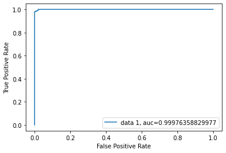

```python
#Affichage de la courbe ROC
roc(y_test,clr.predict_proba(X_test_std)[::,1])
```

**==> L'AUC (Area Under ROC) est de 0.99 (quasiment = 1 qui correspond quasiment au meilleur des cas) : la performance du modèle est très bonne.**

### * Optimisation de la régression logistique

Toujours en utilisant la validation croisée, on peut optimiser les hyperparamètres de la Régression Logistique afin d'optimiser notre modèle : utilisation de la fonction GridSearchCV qui nous retournera le ou les paramètres optimaux.

```python
#Préparation de l'estimateur
model = Pipeline([('scaler', StandardScaler()), ('logistic', LogisticRegression())])

params = {
    'logistic__solver': ["lbfgs", "liblinear", "sag", "saga",'newton-cg'],
    'logistic__C': [0.001, 0.01, 0.1, 1, 10, 100, 1000]}
model_opti = GridSearchCV(model, param_grid=params, cv=cross_validation )
model_opti.fit(X_train, y_train)

print('\033[1m',"Paramètres optimaux GridsearchCV :  ",'\033[0m')
print("------------------------------------\n")
print(model_opti.best_estimator_)
model_opti = model_opti.best_estimator_

#Prédictions avec le modèle optimal
y_pred_test1 = model_opti.predict(X_test)
print('\033[1m',"\n\nTest score :", round(model_opti.score(X_test, y_test)*100,2),'%','\033[0m')
```

```
GridSearchCV(cv=StratifiedKFold(n_splits=5, random_state=42, shuffle=True),
             estimator=Pipeline(steps=[('scaler', StandardScaler()),
                                       ('logistic', LogisticRegression())]),
             param_grid={'logistic__C': [0.001, 0.01, 0.1, 1, 10, 100, 1000],
                         'logistic__solver': ['lbfgs', 'liblinear', 'sag',
                                              'saga', 'newton-cg']})
```

```
 Paramètres optimaux GridsearchCV :
------------------------------------

Pipeline(steps=[('scaler', StandardScaler()),
                ('logistic', LogisticRegression(C=0.1, solver='liblinear'))])


Test score : 99.33 %
```

```
 Matrice de confusion :
-----------------------
```

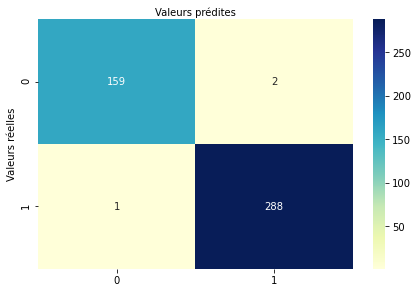

```
Accuracy: 99.33 %
Precision: 99.31 %
Recall (sensibilité): 99.65 %


 Courbe ROC :
--------------
```

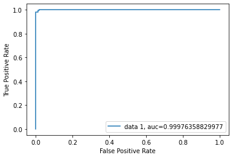

```python
#Affichage matrice de confusion
matrice_confusion(confusion_matrix(y_test,y_pred_test1))

#Affichage métriques diverses
print('\033[1m',"\n\nAccuracy:",round(metrics.accuracy_score(y_test, y_pred_test1)*100,2),'%')
print("Precision:",round(metrics.precision_score(y_test, y_pred_test1)*100,2),'%')
print("Recall (sensibilité):",round(metrics.recall_score(y_test, y_pred_test1)*100,2),'%''\033[0m','\n\n')

#Affichage de la courbe ROC
roc(y_test,model_opti.predict_proba(X_test)[::,1])
```

==> La matrice de confusion montre une légère amélioration de l'accuracy et de la precision  
==> Pas de différence significative au niveau de la courbe ROC : l'AUC est aussi de 0.99 (quasiment = 1 qui correspond quasiment au meilleur des cas) : la performance du modèle est là aussi très bonne.  
**Conclusion : le modèle sklearn "model_opti" est pour l'instant le modèle le plus robuste.**

### **c) Apprentissage supervisé : REGRESSION LOGISTIQUE (librairie StatsModels)**

```
Optimization terminated successfully.
         Current function value: 0.032043
         Iterations 11
const           2.398850
diagonal       -0.182781
height_left    -0.752269
height_right   -0.765667
margin_low     -3.459096
margin_up      -1.972365
length          4.801449
dtype: float64
```

Logit Regression Results

| Dep. Variable: | y | No. Observations: | 1050 |
| --- | --- | --- | --- |
| Model: | Logit | Df Residuals: | 1043 |
| Method: | MLE | Df Model: | 6 |
| Date: | Tue, 16 Aug 2022 | Pseudo R-squ.: | 0.9491 |
| Time: | 12:49:09 | Log-Likelihood: | -33.645 |
| converged: | True | LL-Null: | -660.45 |
| Covariance Type: | nonrobust | LLR p-value: | 1.187e-267 |

|  | coef | std err | z | P>\|z\| | [0.025 | 0.975] |
| --- | --- | --- | --- | --- | --- | --- |
| const | 2.3989 | 0.409 | 5.859 | 0.000 | 1.596 | 3.201 |
| diagonal | -0.1828 | 0.366 | -0.500 | 0.617 | -0.900 | 0.534 |
| height_left | -0.7523 | 0.410 | -1.835 | 0.067 | -1.556 | 0.051 |
| height_right | -0.7657 | 0.353 | -2.172 | 0.030 | -1.457 | -0.075 |
| margin_low | -3.4591 | 0.674 | -5.135 | 0.000 | -4.779 | -2.139 |
| margin_up | -1.9724 | 0.495 | -3.988 | 0.000 | -2.942 | -1.003 |
| length | 4.8014 | 0.810 | 5.927 | 0.000 | 3.214 | 6.389 |

Possibly complete quasi-separation: A fraction 0.45 of observations can be  
perfectly predicted. This might indicate that there is complete  
quasi-separation. In this case some parameters will not be identified.

```
 Matrice de confusion :
-----------------------
```

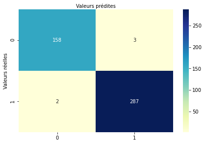

```
Accuracy: 98.89 %
```

```python
#Avec statmodels : régression logistique avec données standardisées
#Création des variables
# y (variable expliquée):
ysm = billets['is_genuine']
ysm.replace([False,True], [0,1], inplace=True)

# X (variables explicatives):
Xsm = billets.drop('is_genuine', axis=1)


#Séparation jeu d'entrainement et jeu de test
X_trainsm, X_testsm, y_trainsm, y_testsm = train_test_split(Xsm, ysm, test_size=0.3,random_state=42)

#Données standardisées
std_scale = preprocessing.StandardScaler().fit(X_trainsm,y_trainsm)
X_train_scaled=std_scale.transform(X_trainsm)
X_train_scaled_df = pd.DataFrame(X_train_scaled, columns=Xsm.columns)

X_test_scaled=std_scale.transform(X_testsm)
X_test_scaled_df = pd.DataFrame(X_test_scaled, columns=Xsm.columns)

#Ajout d'une constante pour Statsmodels
X_trainsm_std = sm.tools.add_constant(X_train_scaled_df)
X_testsm_std = sm.tools.add_constant(X_test_scaled_df)

y_trainsm=y_trainsm.values.reshape(-1,1)

# on ajuste le modèle
modellogit = sm.Logit(y_trainsm, X_trainsm_std).fit()
print(modellogit.params)
modellogit.summary()

prediction=modellogit.predict(X_testsm_std)
y_predsm= np.where(prediction > 0.5,1 , 0)

matrice_confusion(confusion_matrix(y_testsm, y_predsm))

# accuracy score of the model
print('\033[1m',"\n\nAccuracy:",round(metrics.accuracy_score(y_testsm, y_predsm)*100,2),'%')
```

**==> Précision du modèle : 98,89%**.

Le waring nous indique qu'il existe des variables qui prédisent parfaitement 45% des observations ==> dû au jeu de tests conçu pour les besoins de l'étude ?  
Certaines des variables obtenues ont des p-valeurs inférieures au niveau de test de 5 %, ce qui nous indique qu'elles sont bien **significatives ('height_right', 'margin_up', 'margin_low' et 'length')** et d'autres sont **non significatives (ces paramètres ne sont pas significativement différents de 0 comme 'diagonal' et 'height_left').**  
Nous allons donc enlever ces variables non significatives

```
Optimization terminated successfully.
         Current function value: 0.033791
         Iterations 11
const           2.361904
height_right   -0.951870
margin_low     -3.306853
margin_up      -1.923167
length          4.796256
dtype: float64
```

Logit Regression Results

| Dep. Variable: | y | No. Observations: | 1050 |
| --- | --- | --- | --- |
| Model: | Logit | Df Residuals: | 1045 |
| Method: | MLE | Df Model: | 4 |
| Date: | Tue, 16 Aug 2022 | Pseudo R-squ.: | 0.9463 |
| Time: | 12:49:09 | Log-Likelihood: | -35.481 |
| converged: | True | LL-Null: | -660.45 |
| Covariance Type: | nonrobust | LLR p-value: | 2.365e-269 |

|  | coef | std err | z | P>\|z\| | [0.025 | 0.975] |
| --- | --- | --- | --- | --- | --- | --- |
| const | 2.3619 | 0.392 | 6.027 | 0.000 | 1.594 | 3.130 |
| height_right | -0.9519 | 0.372 | -2.562 | 0.010 | -1.680 | -0.224 |
| margin_low | -3.3069 | 0.559 | -5.915 | 0.000 | -4.403 | -2.211 |
| margin_up | -1.9232 | 0.478 | -4.021 | 0.000 | -2.861 | -0.986 |
| length | 4.7963 | 0.754 | 6.360 | 0.000 | 3.318 | 6.274 |

Possibly complete quasi-separation: A fraction 0.42 of observations can be  
perfectly predicted. This might indicate that there is complete  
quasi-separation. In this case some parameters will not be identified.

```
 Matrice de confusion :
-----------------------
```

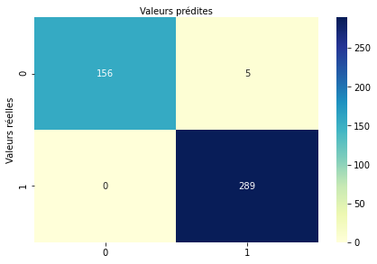

```
Accuracy: 98.89 %
```

```python
#Suppression des variables non significatives et création d'un nouveau modèle de régression logistique

#Création des variables
# y (variable expliquée endogène):
ysmbis = billets['is_genuine']
ysmbis.replace([False,True], [0,1], inplace=True)

# X (variables explicatives exogènes):
Xsmbis = billets.drop(['diagonal','height_left','is_genuine'], axis=1)

#Séparation jeu d'entrainement et jeu de test
X_trainsmbis, X_testsmbis, y_trainsmbis, y_testsmbis = train_test_split(Xsmbis, ysmbis, test_size=0.3,random_state=42)


#Données standardisées
std_scale = preprocessing.StandardScaler().fit(X_trainsmbis,y_trainsmbis)
X_train_scaledbis=std_scale.transform(X_trainsmbis)
X_train_scaled_dfbis = pd.DataFrame(X_train_scaledbis, columns=Xsmbis.columns)

X_test_scaledbis=std_scale.transform(X_testsmbis)
X_test_scaled_dfbis = pd.DataFrame(X_test_scaledbis, columns=Xsmbis.columns)

#Ajout d'une constante pour Statsmodels
X_trainsm_stdbis = sm.tools.add_constant(X_train_scaled_dfbis)
X_testsm_stdbis = sm.tools.add_constant(X_test_scaled_dfbis)

y_trainsmbis=y_trainsmbis.values.reshape(-1,1)

# on ajuste le modèle
modellogitbis = sm.Logit(y_trainsmbis, X_trainsm_stdbis).fit()
print(modellogitbis.params)
modellogitbis.summary()

predictionbis=modellogitbis.predict(X_testsm_stdbis)
y_predsmbis= np.where(predictionbis > 0.5,1 , 0)

matrice_confusion(confusion_matrix(y_testsmbis, y_predsmbis))

# accuracy score du modèle
print('\033[1m',"\n\nAccuracy:",round(metrics.accuracy_score(y_testsmbis, y_predsmbis)*100,2),'%')
```

Le pseudo R² est de 0.94 : notre modèle explique donc la majorité de la variance observée.  
Les p_value pour chacune des variables est < 5% : chacune d'elle est donc bien significative.

```
 Courbe ROC :
--------------
```

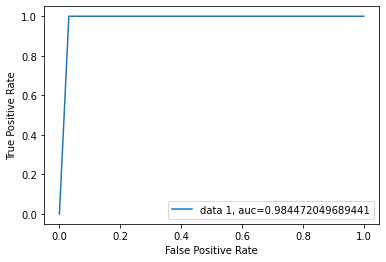

```python
#Affichage de la courbe ROC
roc(y_testsmbis,y_predsmbis)
```

==> l'AUC est de 0.98 (quasiment = 1 qui correspond quasiment au meilleur des cas) : la performance du modèle est là aussi très bonne mais reste inférieure au modèle optimisé de sklearn 'model_opti'. **C'est donc le modèle 'model_opti' que nous utiliserons pour les prédictions.**

### **d) Sauvegarde du modèle optimal**

```python
#sauvegarde du modèle
import pickle


# modèle scikit learn avec données standardisées
pickle.dump(model_opti, open("model_opti.pkl", "wb"))
```